# Do Families Face Higher Inflation?

An experiment, vibe-coded by Claude Opus 5.5 · Mike Konczal

Oct 14, 2026

## Intro: What are we investigating?

Families with children buy more groceries, child care, cars and school supplies. Did that mix give them a higher inflation rate than other households?

We built two baskets from the government’s household spending survey: one for families with children, one for single-person and other households. We priced both with the same official CPI item prices and compared how fast each rose from December 2019 to July 2026 as well as within the 2010s.

**Did the family basket rise faster?**

## Intro: We expected little difference

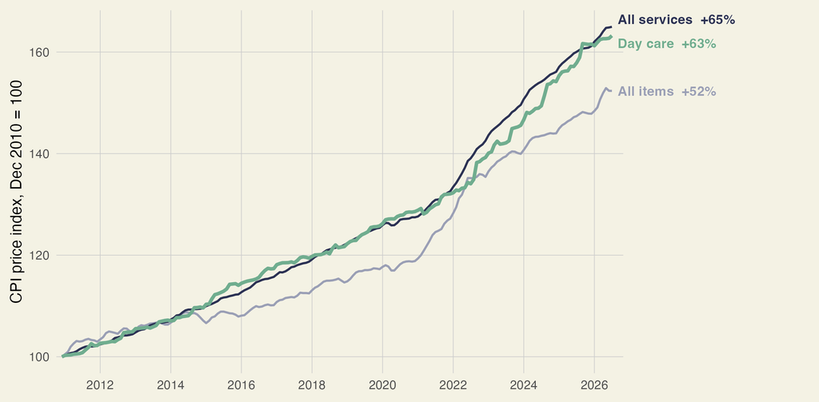

**Child care prices have grown with other services.** Since December 2010, day care is up 63% and all services 65%.

**Child care is a small slice of the budget.** For married couples with children it is 1.8% of spending.

**The problem is the size of the bill, not its inflation rate.** When the oldest child is under 6, married couples average **$5,586 a year** on child care, 6.4% of spending, and that average includes families who pay nothing. Those costs are very high for a few years, then fall to 1.6% of spending once the oldest child is 6 to 17.

## Intro: Different spending shares

**Families spend a bigger share on:**

- Child care
- Groceries
- Cars and gas
- Education

**Single-person and other households spend a bigger share on:**

The index measures how the spending mix affects inflation. Each group gets the same CPI price change for a given item. It cannot capture differences in the prices households actually pay.

## Data: How we built it

1

Budgets

What each household type spends, from BLS’s Consumer Expenditure Survey

→

2

Prices

Match every spending category to its official CPI price series

→

3

Indexes

Price each group’s spending shares with the same CPI item indexes

→

4

Compare

Check the gap against survey error, other household cuts, and other time periods

## Data: The budgets

The **Consumer Expenditure Survey** is BLS’s survey of household spending. We use its published annual averages by household type, the same survey BLS uses to weight the CPI.

The family group combines married couples with children of any age (30.3 million consumer units in 2024) and one-parent units with a child under 18 (6.2 million), weighted by unit counts. The main comparison is single-person and other units (64.4 million). We also compare with all units and childless married couples.

- 41 spending categories, every year from 1988 to 2024
- Each category checked against the survey’s own published totals: 201 checks, no failures
- Standard errors from BLS’s published tables, so every comparison carries a margin of error

## Data: Where the budgets differ

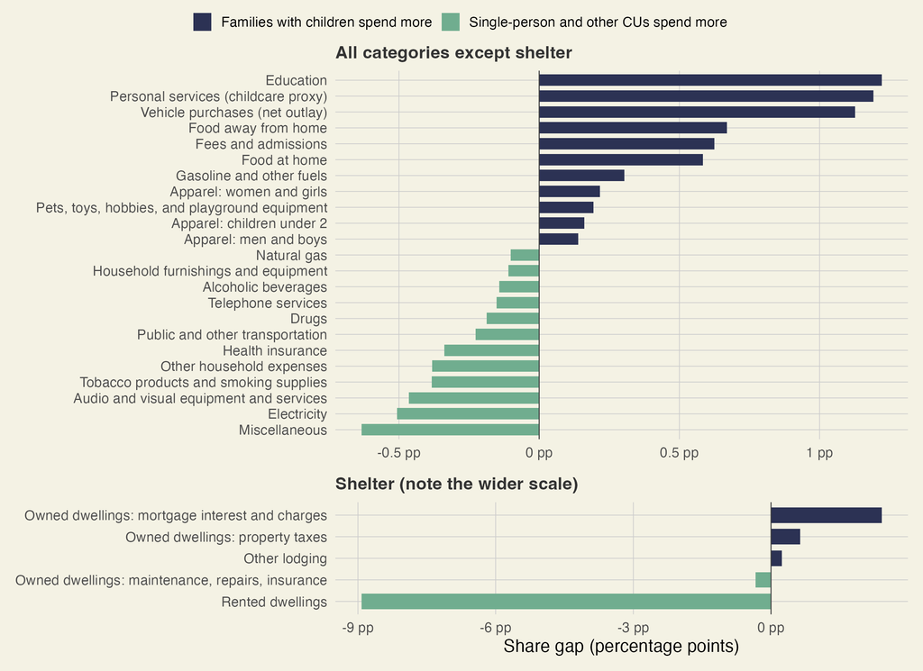

Family share minus single-person-and-other share, 2024. Rent has the largest gap.

## Data: Pricing the budgets

We match 37 spending categories to 62 CPI price series. Vehicle spending, for example, combines prices for new, used and leased vehicles.

**Owner housing uses rental equivalence.** CE asks owners what their home would rent for; BLS uses that answer to weight owners’ equivalent rent in the CPI. We use the same measure.

Built this way, our all-household index differs from official CPI by 0.1 percentage point on average across 12-month rates. This checks the aggregate fit, but cannot test prices paid within each household type.

## Analysis: The result

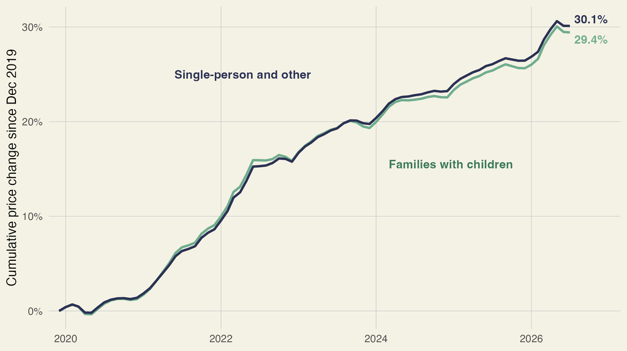

| Dec 2019 to Jul 2026 |  |
| --- | --- |
| Families with children | **+29.4%** |
| Single-person and other | **+30.1%** |
| **Gap** | **−0.7 pts** |

The gap is about −0.1 point a year. The approximate 95% sampling margin is ±0.41 points with independent survey-year errors and ±0.95 under the cross-year bound.

**No family inflation premium in the spending-mix index.** Across nine baskets, the family-minus-single/other gap runs from −1.0 to +0.1 points. The result also survives alternative price inputs and index formulas.

## Analysis: Our method matches BLS’s own index

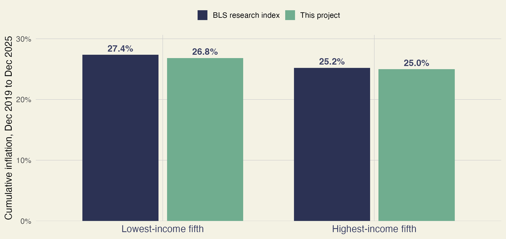

## Analysis: Across family definitions

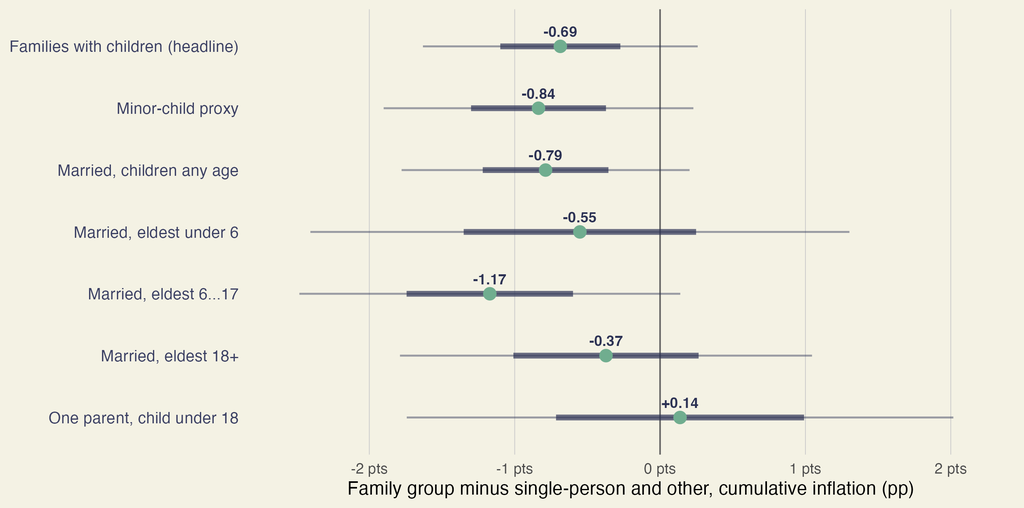

Each group is compared with single-person and other households, Dec 2019 to Jul 2026. Thick bars show approximate 95% intervals under independent survey-year errors; thin bars use a cross-year correlation bound. The one-parent estimate is slightly positive but imprecise. The minor-child group is a published-table proxy, not every household with a child under 18.

## Analysis: Compared with whom?

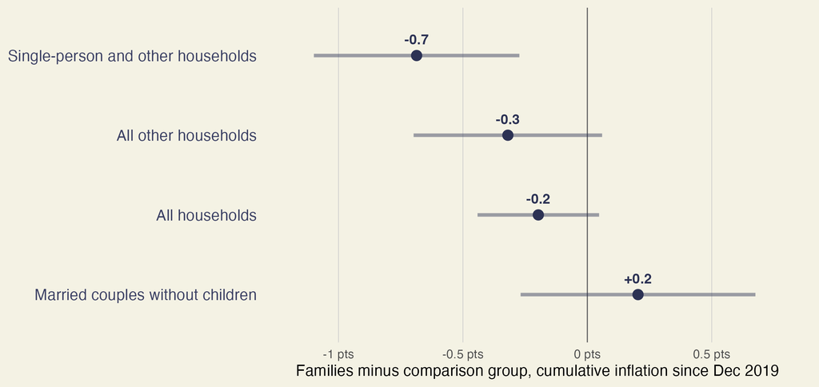

The largest negative gap is against single-person and other households, whose basket has more housing. Against all households the gap is −0.2 points; against married couples without children, who spend more on slow-rising medical care, it is +0.2. Neither is outside the margin of error. **These group baskets have similar inflation.**

## Analysis: The gap predates the pandemic

| Window | Basket and family group | Gap vs. single/other |
| --- | --- | --- |
| 2014–19 | CPI-concept, headline group | −1.05 pts |
| 2014–19 | CPI-concept, minor-child proxy | −1.02 pts |
| 2019–26 | CPI-concept, headline group | −0.69 pts |
| 2014–19 | Ex-shelter, headline group | −0.22 pts |
| 2010–19 | Ex-shelter, unpooled medical, headline group | +0.07 pts |

The CPI-concept index begins in 2014: CE rental-value data start in 2012 and the index uses two-year-old weights. Its pre-pandemic gap is below zero even under the cross-year uncertainty bound. The 2010–19 check excludes shelter, prices medical care without pooling and has no sampling interval, so compare it with the 2014–19 ex-shelter row, not the headline. Outside shelter, neither window shows a sizable family premium.

## Analysis: The 2021–22 episode

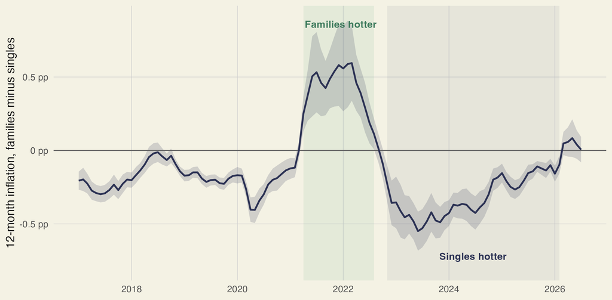

Twelve-month inflation, families minus single-person and other households, with an approximate 95% sampling interval. From April 2021 to August 2022 the family basket ran up to 0.6 points hotter. The cumulative difference over 2020–22 was +0.23 points (independent-year p = 0.15). From late 2022 rent drove a reversal: the single/other basket ran 0.65 points hotter over 2023–24. By July 2026 the 12-month gap was near zero.

## Analysis: Housing mattered before 2020 too

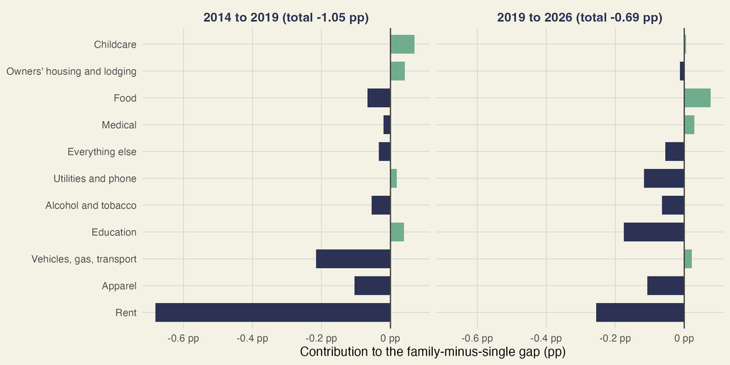

Contribution of each spending area to the gap. From 2014 to 2019, families trailed single/other households by 1.05 points. Rent contributed −0.68 points: it rose 20% while overall prices rose 9%, and single/other households put more than twice the budget share toward rent. Vehicles and gasoline contributed another −0.22 points.

## Analysis: Income groups differ more

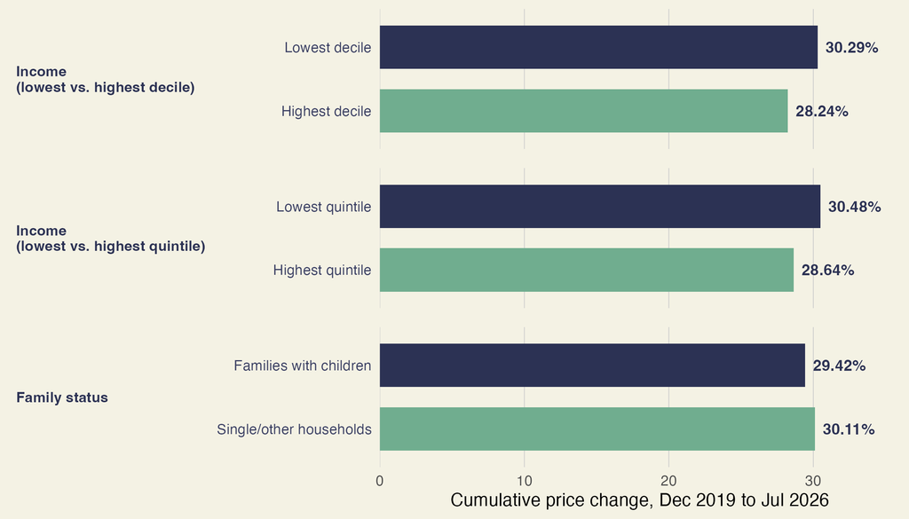

Same method, same years. The lowest-income tenth of households saw prices rise 2.1 points more than the top tenth. The family gap is a third that size and runs the other way.

## Why isn’t it higher: Inflation rates depend on spending shares

Families spend $105,000 a year, against $57,000 for single-person and other households. That gives them a bigger dollar hit. It does not give them a faster rate. A household that buys twice as much of the same basket has the same inflation rate.

## Why isn’t it higher: Which prices create a gap?

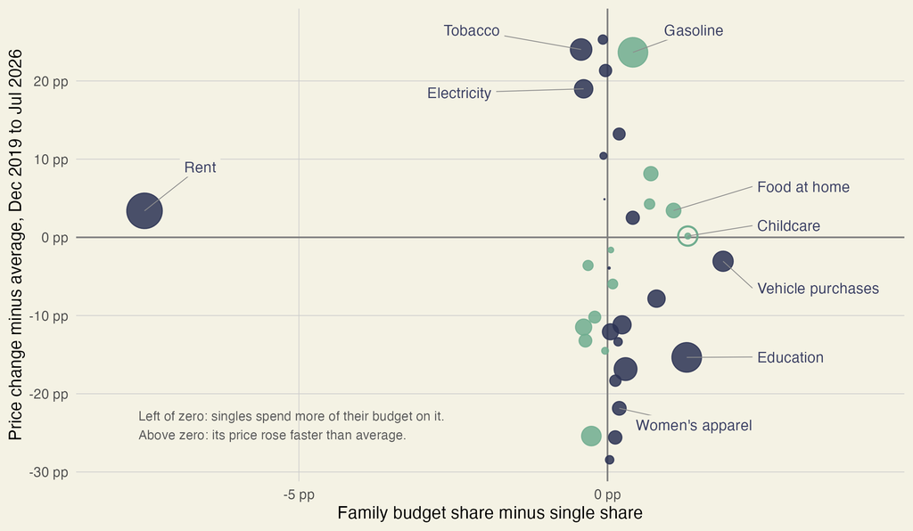

A category moves the gap when families buy more of it **and** its price rose faster than everything else. Rent, far to the left, pulled families down most. Education (tuition up 14% against 30% overall) pulled them down too, but that is mostly parents of college-age children. Gasoline pushed them up. Child care sits on the zero line.

## Why isn’t it higher: Child care adds about zero

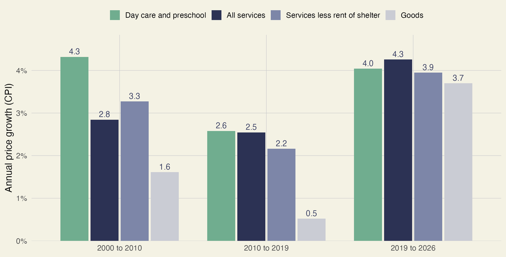

Since 2010 day care prices have risen at the same pace as services overall (in the 2000s they ran faster). Services are mostly labor, and labor costs climb faster than goods prices. In the 2010s day care beat overall inflation only because goods prices barely moved.

**Our starting intuition held.** Families put about eight times as much of their budget into child care, but day care prices rose 29.8% since Dec 2019, against 29.9% for all items. So child care adds about zero to the gap.

## Why isn’t it higher: Housing’s share falls with household size

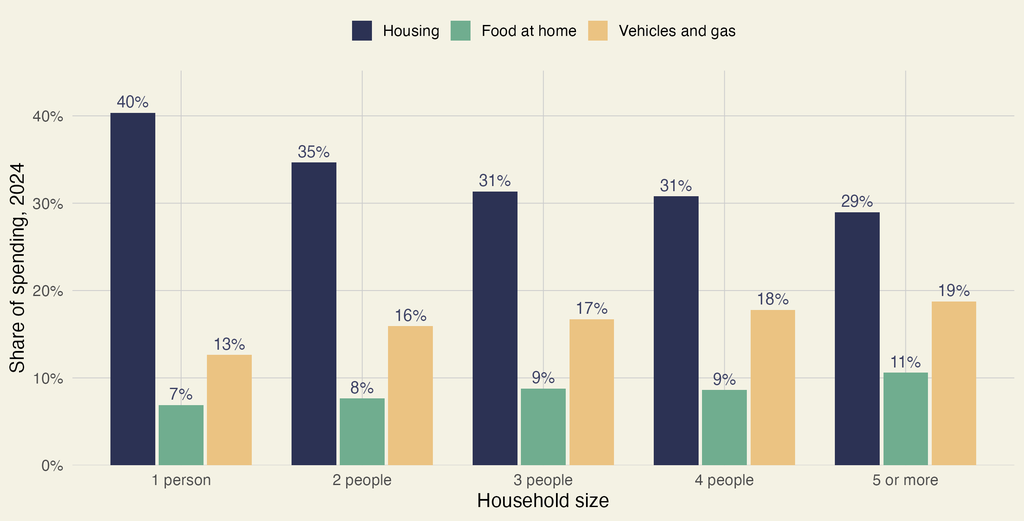

## Caveats: Dollar cost of a fixed basket

|  | Inflation, Dec 2019 to Jul 2026 | Extra cost per year for the 2019 non-housing basket | Share of spending on groceries, utilities and housing |
| --- | --- | --- | --- |
| Married couple with children | 29.3% | **$16,300** | 36.6% |
| Single-person and other | 30.1% | $8,100 | 43.3% |
| One parent, child under 18 | 30.2% | $9,500 | **43.0%** |
| *Lowest-income fifth (reference)* | 30.5% | $5,800 | 46.3% |

The extra cost of the fixed 2019 non-housing basket is twice as large for married families as for the single/other group, at a slightly lower rate. Single parents have a necessity share closer to the bottom income fifth than to married couples. The index alone cannot measure hardship.

## Caveats: Scope and uncertainty

- **Prices paid.** Everyone is charged the same price for the same item here. Scanner-data research finds households pay quite different prices within an item.
- **Cash versus CPI housing costs.** Owners are charged their home’s rental value, as in CPI. An owner with a locked-in mortgage saw cash housing costs rise less than that; a recent buyer saw them rise more.
- **Age.** The average reference person is 44 in the family group and 53 in the single/other group. The published tables do not allow an age-conditioned comparison; medical spending helps explain the result against childless couples.
- **Survey error.** Margins of error use BLS expenditure standard errors, with category errors treated as uncorrelated. Under the cross-year correlation bound, the headline gap is not distinguishable from zero.
- **Index formula.** The headline uses two-year-old spending weights, following CPI practice since 2023. An annual-share Törnqvist check, which approximates the chained CPI concept, gives a smaller gap: −0.5 rather than −0.7.